# My Titled

## Linear models

Linear regression is a model based approach which imposes that the conditional expectation is linear in its arguments $f(x) = x'\theta$.

For the **simple linear model** where each preditor enters aas an argument as it is this gives $g(z_{i,t}) =z_{i,t}' \theta$. The parameters, $\theta$ of the model can be estimated using the training data, most popularly by *least squares*, which picks the parameters to minimize the objective function of residual sum of squares

$$RSS(\theta) = \sum_{i=1}^N\sum_{t=1}^T (r_{i,t+1} - g(z_{i,t};\theta) )^2$$
Here there are $T\times N$ observations as the pooled estimate of $\theta$ over the panel of individual stocks is considered.

It is well known that the linear model has a low bias However, in the face of a large amount of predictors relative to number of observations, the linear model will have large variance. In this context, as Gu, Kelly, and Xiu (2018) points out, what really matters is the no. of predictors $p$ vs. time periods $T$, as stock returns typically share a large cross-sectional dependence which limits the information gained by adding observations along the cross-section.

### Penalized Regression

Although there are variable subset select procedures that can be performed even on large models, like Forward- and Backward-Stepwise selection[^3], a more efficient way to reduce the complexity of the linear model is to impose constraint on the size of $\theta$. This is done via a penalty in the objective function, such that parameters are estimated by minimizing

$$\mathcal{L}(\theta,\cdot) = RSS(\theta) + \phi(\theta, \cdot)$$
where the penalty function $\phi$ depends on a tuning parameter.

For **Ridge regression** an L2 penalty is applied to the parameters. In this case $\phi(\theta, \lambda) = \lambda \|\theta \|_2^2$ such that the parameters are constrained in a hypersphere in the parameter space with center at the origin. Shrinking the parameters in this way introduces bias to the linear model but can be shown to reduce the variance. In terms of expected prediction error this often leads to better out of sample predictions in high dimensional problems.

Another proposed way of shrinking the parameters is with an L1 penalty, $\phi(\theta, \lambda) = \lambda \|\theta \|_1$. Regression with this penalty is known as **Lasso regression**. Geometrially this means that the parameters are constrained in a “diamond” (L1 unit circle), which will tend to set many parameters to exactly zero and thus working as actual subset selection of the variables. This is opposed to the Ridge regression that will never set parameters to zero.[^4].

Finally a combination of the two approaches to the penalty has been proposed by Zou and Hastie (2005), known as the **Elastic Net**. It uses a linear combination between the penalties, $\phi(\theta, \lambda, \alpha) = \lambda \left( \alpha \|\theta \|_2^2 + (1-\alpha) \|\theta \|_1 \right)$. For $\alpha < 1$ the constraint boundary still has “kinks” at $\theta_j = 0$ and thus still enjoys the property of the Lasso of deselecting some variables.

### PCR and PLSR

Principal Components Regression and Partial Least Squares Regression are linear models that consider certain linear combinations of the predictors and use these as arguments in the linear model. Such methods are derived to reduce the dimension of the problem, which is especially useful if there are a large number og highly correlated predictors. The two methods differ in how they utilise the inputs.

**PCR** seeks to use as much variation from the inputs in as few variables as possible. It does this by using the principal components of the input data. The largest principal component is the direction in the input space that yields the largest variance if all input point where projected onto this line. Call a vector point in this direction $v_1 \in \mathbb{R^p}$, then the first/largest principal component is $X v_1$. The second principal component maximises this variance subject to being orthogonal to $v_1$. There are in total $P$ principal components and the choice of how maný to include in the linear model as arguments is tuning parameter subject to validation.

The second approach, **PLSR**, instead tries to maximise the covariance with the responses (returns). In essence the first argument, the first partial squares direction, put forward to the model is a weighted sum of the predictors where predictors (after having been standardized) with higher covariance with the response have higher weights. To include more directions the inputs are orthogonalized (by gram-schmidt) and the procedure is repeated again. How many arguments to give the model is again a tuning paramenter.

### Generalized Linear Model

The final linear model considered in this exercise is the **GLM**. Each predictor is transformed by a *linear basis expansion* and a linear model is then fit to the new space of derived inputs. Because the basis functions most often are non-linear such a model can capture non-linearities in the data with the regression function/surface $f(x)$ being non-linear. However the model is still linear in the coefficients to be estimated which is such a model is also referred to as “additive”.

In this exercise a second order spline expansion is chosen, as in Gu, Kelly, and Xiu (2018). A quadratic spline is a piecewise/local second order polynomial but where the it is restricted to be continuous and have a continuous first derivatives at the “knots”. Having restricted the local polynomials to be quadratic, the only tuning parameter is the no. of knots, more knots leading to a more complex model.

As the number of parameters in such a model is much greater than the simple linear model it is surely advantageous to use a shrinking method. In this setting the Group Lasso is useful. It gives the penalty to the objective function

$$\phi(\theta, \lambda, K) = \lambda \sum_{j=1}^P \left( \sum_{k=1}^K \theta_{j,k}^2 \right)^{1/2}$$

where P is the no. of predictors available and K is the no. of terms in a given spline considered. The Group Lasso penalty has the desirable property that terms based on the same predictor are set to zero together. Thus for the GLM considered here, the no. og knots and the penalty parameter $\lambda$ are the tuning parameters.

## Tree-based Models

Tree regression takes completely different approach to approximating the condtional expectation of the response given the inputs, $f(x) = E[Y|X=x]$. Instead of using a continuous surface over the predictor space the approach is instead to divide the predictor space into rectangles and treat $f(x)$ as constant in each rectangle. This is a very direct approach to approximate $E[Y|X=x]$, where the (empirical) mean is conditions not at the point $x$ but in on an area around $x$. The size of each rectangle is what determines the complexity of a tree regression.

To find the optimal division of the predictor space by considering all options is computationally infeasible. The most common procedure is a *greedy* one where at each step the space or a “branch” of the space is split by a predictor and a split value, both of which are chosen to reduce the RSS maximally for that step. Each split creates two new branches. This procedure known as *recursive binary splitting*.

Splitting/branching halts when the tree reaches a prespecified stopping criterion. In this paper the stopping criterion is based on a minimal no. of observations in each terminal node (“leaf”) or reach of a depth limit, both are chosen as tuning parameters based on the validation sample.

Unlike the GLM where individual predictors can predict in a non-linear fashion, regression trees allow for a more flexible non-linear effects, particularly in the form interactions between variables. A tree divides the p-dimensional input space into (hyper)rectangles which allows for interactions for up to all p predictors. A regression tree, however, suffers from high variance in the sense that a small perturbation in the input values can lead to a large change in a given tree. This amounts to easily overfitting on the training data. The variance issue of trees has been very successfully addressed by forecasting based on averaging over many trees, a method known as ensemble learning, where typically simple/shallow trees are used. Two ways of this are considered approach, “boosting” and “bagging”.

Boosting fits an oversimplified/“shallow” tree on the training data and then fits a consecutive tree on the residuals from the first tree. Then the sum of the forecasts for the two trees is considered as the forecast, but where the second tree’s forecast (of the residuals) is shrunk by a factor between $\nu \in (0,1)$. A third tree is added to these residuals and so on.. Tuning parameters to be chosen are the limit depth of each tree, the shrinkage factor and the total number of trees to fit. For boosting a maximal of 6 splits is typically considered, hence the “slow learning” approach.

For the bagging, many trees are fitted using (nonparametric-)bootstrap samples and then averaged. To avoid using the most influential variables for the first splits in all the trees, only a random subset of the predictors are considered for splitting at each branch. This amounts to a **Random Forest**. The Random Forest is fairly straightforward to use “out-of-the-box” and performs very well without having a lot of tuning parameters to be chosen. The most important tuning parameter is the fraction of predictors available for each split. The number of trees should be chosen but the MSE will stabilize after a while. The node size should also be chosen, as a stopping criterion, which also represents a bias-variance trade-off as smaller nodes will lead to more complex trees.

### Neural Networks

The final learning method considered, which is in a category of its own, is the **Neural Network** (NN). The inputs are filtered through “hidden layers” to create new arguments to use as predictors in a linear model. This is analogous to PCR and PLSR, however, the neural network is not as systematic and is much more flexible. Figure 1 gives a simple illustration of a Neural Network in the regression context. There are 4 input/predictors and one hidden layer with 3 “neurons”. Each neuron gets its value as linear combination of all the neurons from the previous layer. Without any hidden layer this is just a simple linear regression.

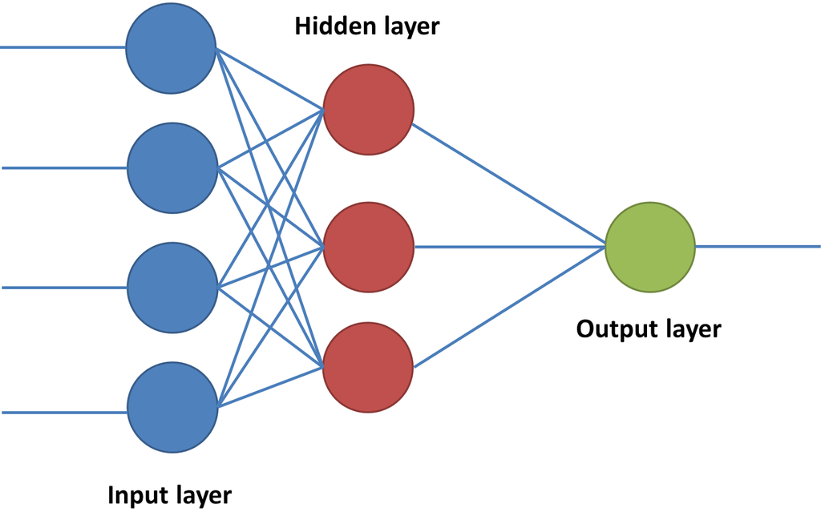

Illustration of simple Feed-forward Neural Network

The NN allows for non-linear regression by applying a non-linear “activation function” to each neuron in the hidden layers. In fact a NN with just a single hidden layer containing a finite number of neurons can approximate continuous functions on compact subsets of $\mathbb{R}^2$ (see Cybenko 1989). The NN’s in this exercise uses the ReLU activation function $ReLU(x) = \max\{x,0\}$. The NN’s flecibility is also one of its greatest critisisms and it is often described as a “black box” without any meaning, just pure pattern recognition.

For the number of parameters in a neural network, consider a NN with one hidden layer, with, say, $n$ neurons. There are $p$ predictors, thus each neuron in the hidden layer has to it associated (p+1) parameters (it’s a linear model in itself). This gives $n \times(p+1)$ parameters in the hidden layer. Additionally, there will be $(n+1)$ parameters in the output layer which constitute the linear model for predicting the output with the neurons from the hidden layer. In all $n \times(p+1) + (n+1)$ parameters in the neural network with one hidden layer containing $n$ neurons. The large number of parameters are obviously a problem for contexts with few observations for estimation, like in the context of economics and finance. Thus in these contexts shallow networks with few neurons in each tend to perform better.

In this exercise NN’s with layers ranging from 1-3 are considered, and the no. of neurons in each layer is set by the geometric pyramid rule (see Masters 1993). In estimation RRS is used as an objective. It is optimized by Stochastic Gradient Descent (SGD) and an l1 penalty on the parameters is used to prevent overfitting - this is also called “weight decay”. Another measure against overfitting is “early stopping” which evaluates the error on a validation set after each epoch in the SGD. If the validation error increases for 3 epochs in a row the fitting is haulted. Important tuning parameters are the parameter penalties and the step size in the SGD.

### Evaluation

In this paper model performance is based on the R-squared measure. Both for in-sample and out-of-sample the RRS is compared to the total sum of squares based on the historical mean of the returns, i.e the average of returns before the test sample. Out-of-sample R-squared is then

$$R^2_{OOS} = 1 - \frac{\sum_{(i,t)\in\mathrm{test}} (r_{i,t+1} - \hat{r}_{i,t+1} )^2}{\sum_{(i,t)\in\mathrm{test}} (r_{i,t+1}- \bar{r}_{train})^2 }$$
Models can be compared pairwise for their out-of-sample predictive ability by the Diebold-Mariano test[^5]. The test considers the difference in errors

$$d_t = \left(e_{i,t}^{(1)}\right)^2 - \left(e_{i,t}^{(2)}\right)^2$$

where errors $e_{i,t}$ are transformed with the square - the absolute value could also be used[^6]. Under the null hypothesis both model perfrom equally well, $\bar{d}= 0$ and the limiting distribution is

$$\sqrt{T}\bar{d} \xrightarrow[]{d} N\left(0, \sum_{k=-\infty}^{\infty} \gamma_d(k)\right)$$

given that this second moment is bounded. The long run variance of the sample mean is[^7]

$$\mathrm{Var}(\sqrt{T}\bar{d}) \xrightarrow[]{T\rightarrow \infty} \sum_{k=-\infty}^{\infty} \gamma_d(k)$$

Thus test statistics will be

$$\frac{\bar{d}}{\sqrt{ \frac{\sum_{k=-\infty}^{\infty} \gamma_d(k)}{T} }}$$

which is asymptotically standard normal. Newey and West (1987) propesed HAC estimator is used to get a consistent estimate of the variance.

# Simulation

The simulation is based on the experiment outlined in Gu, Kelly, and Xiu (2018). The experiment is set up to compare model performance for different data generating processes.[^8]

DGP-a is a linear DGP such that returns in the following period for individual stock i is a linear combination of three of the respectively 100 and 200 available predictors. To the extent that machine learning models is thought to capture non-linearities among the predictors, the simple linear model (OLS)[^9] should perform relatively well in this. A different number of total predictors for each stock is considered to evaluate the improvement shrinking and dimensionality reductions methods can provide.

The other DGP considered, DGP-b is a non-linear counterpart. The same predictors enter the true DGP in the construction of returns/responses, however, each variable enter as a non linear transformation.

Specifically the setup is like this. The returns are made up by the conditional expectation, g, given the predictors, plus an error.

$$r_{i,t+1}= g(z_{i,t}) + e_{i, t+1}$$
$e_{i, t+1}$ is a combination of a normal error and a student error, it is common to both DGP’s[^10]

Choosing the data generating process is chooses g. The set of predictors for each stock i, $z_{i,t}$ is made up of individual characteristics, $c_{i,t}$ and interactions of the individual with a common macroeconomic variable, $x_t$. That is, $z_{i,t} = (1, x_t)' \otimes c_{i,t}$. If there are $Pc$ individual characteristics there will thus be $P = 2 \times Pc$ predictors for each individual stock $i$ at time $t$. The individual characteristics are generated using an AR(1) process with normal error and with AR-coefficient randomly distributed uniform(0.9, 1), such that there is a high degree of persistence in the characteristics. The macroeconomic variable, $x_t$ is similarly generated as an AR(1) with normal error and AR-coefficient=$0.95$.

$$\begin{aligned}
(a) & = g(z_{i,t}) = (c_{i1,t}, c_{i2,t}, c_{i3,t} \times x_t)\theta_0, \quad \mathrm{where} \quad \theta_0 = (0.2, 0.2, 0.2)' \\
(b) & = g(z_{i,t}) = \left(c_{i1,t}^2, c_{i1,t} \times c_{i2,t}, \mathrm{sgn}(c_{i3,t} \times x_t) \right)\theta_0, \quad \mathrm{where} \quad \theta_0 = (0.04, 0.03, 0.012)'
\end{aligned}$$

Due to a computing power issue a slight deviation from the simulation study in Gu, Kelly, and Xiu (2018) is that the number of firms (N) is 100 instead of 200 and the no. of periods (T) is 90 instead of 180. It is not clear in the paper whether or not an expanding window with recursive estimation is considered in the simulation study. Due to the computing power issue a fixed window is used here where only one estimation is needed for each simulation repetition. This decision should not have a large impact as the DGP remains the same over “time” in the simulated data.

# Empirical Exercise

Given data compiled for the paper Welch and Goyal (2008)[^11]. The sample considered runs from 1947-03-01 to 2017-06-01. The data is monthly in frequency but some variables are only updated on quarterly or annual basis’. Index is the S&P 500 w/o dividends.

The data is divided into training, validation and test samples. The training sample runs in 1947-1982, 35 years, the validation sample in (1982-2000), 18 years, and finally the test sample the final 17 years.

The crucial difference between the data used in the paper Gu, Kelly, and Xiu (2018, 2018) and the data I have been able to collect is the number of observations. In the data from Welch and Goyal (2008) only returns on the stock market index (S&P500) is considered as the response. Thus the only relevant predictors are aggregated macroeconomic characteristics from the stock market including dividend-price ratio (dp), earnings-price ratio (ep), book-to-market ratio (bm), net equity expansion (ntis), Treasury-bill rate (tbl), term spread (tms), default spread (dfy), and stock variance (svar). In Gu, Kelly, and Xiu (2018) data are obtained at an individual stock level and stock individual characteristics, like growth in common shareholder equity and gross profitability, can therefore be used as predictors. This gives more observation as well as more predictors, which in turn gives more stable estimation and more information to forecast with. Nevertheless is it an interesting exercise to see how the different machine learning models compare in the case I consider here (with no cross-section).

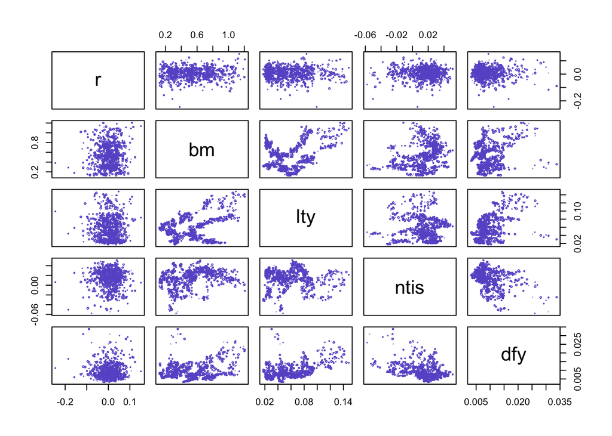

Scatterplot-matrix for the data from Welch and Goyal (2008). It is evident that the signal-to-noise ratio is very low.

# References

Cybenko, George. 1989. “Approximations by Superpositions of a Sigmoidal Function.” *Mathematics of Control, Signals and Systems* 2: 183–92.

Diebold, Francis X, and Robert S Mariano. 2002. “Comparing Predictive Accuracy.” *Journal of Business & Economic Statistics* 20 (1). Taylor & Francis: 134–44.

Friedman, Jerome, Trevor Hastie, and Robert Tibshirani. 2001. *The Elements of Statistical Learning*. Vol. 1. 10. Springer series in statistics New York.

Gu, Shihao, Bryan Kelly, and Dacheng Xiu. 2018. “Empirical Asset Pricing via Machine Learning.” Working Paper 25398. Working Paper Series. National Bureau of Economic Research. https://doi.org/10.3386/w25398.

Hamilton, James D. 1995. *Time Series Analysis*. *Economic Theory. II, Princeton University Press, USA*.

James, Gareth, Daniela Witten, Trevor Hastie, and Robert Tibshirani. 2013. *An Introduction to Statistical Learning*. Vol. 112. Springer.

Kelly, Bryan T, Tobias J Moskowitz, and Seth Pruitt. 2018. “Understanding Momentum and Reversal.” *Available at SSRN 3269897*.

Masters, Timothy. 1993. *Practical Neural Network Recipes in C++*. Morgan Kaufmann.

Newey, Whitney K., and Kenneth D. West. 1987. “A Simple, Positive Semi-Definite, Heteroskedasticity and Autocorrelation Consistent Covariance Matrix.” *Econometrica* 55 (3). [Wiley, Econometric Society]: 703–8. http://www.jstor.org/stable/1913610.

Welch, Ivo, and Amit Goyal. 2008. “A Comprehensive Look at the Empirical Performance of Equity Premium Prediction.” *The Review of Financial Studies* 21 (4). [Oxford University Press, Society for Financial Studies]: 1455–1508. http://www.jstor.org/stable/40056859.

Zou, Hui, and Trevor Hastie. 2005. “Regularization and Variable Selection via the Elastic Net.” *Journal of the Royal Statistical Society: Series B (Statistical Methodology)* 67 (2). Wiley Online Library: 301–20.

[^1]: See Friedman, Hastie, and Tibshirani (2001)
[^2]: Which may or may not be proxies for time-varying beta compensation Kelly, Moskowitz, and Pruitt (2018)
[^3]: see Friedman, Hastie, and Tibshirani (2001), chapter 3.3
[^4]: see again Friedman, Hastie, and Tibshirani (2001), chapter 3.3, for a visual illustration of the difference between Ridge and Lasso penalty.
[^5]: Diebold and Mariano (2002)
[^6]: If doing the test on a panel it makes to average prediction error for each model in each time period, i.e. in the cross-section. This is due to the high error dependence across stocks, which likely violates the conditions for asymptotic normality of the test statistic.
[^7]: see Hamilton (1995)
[^8]: I will give the outline of the experiment. The specifics can be found in the appendix of Gu, Kelly, and Xiu (2018) under the name “Monte Carlo simulations”.
[^9]: Here and in the rest of the paper OLS is meant to be the naive linear model of all predictors entering without transformations. No variable selection is performed. Other linear models considered in the simulation study are the penalty methods of Ridge, Lasso and Elastic net, and the Generalized Linear Model (Generalized Additive Model) where splines of variables are used. The oracle is the linear model where only the true predictors from the DGP enter
[^10]: see Gu, Kelly, and Xiu (2018) for details.
[^11]: The data, including a appendix with sources and description of the data, can be found on Amit Goyal’s website http://www.hec.unil.ch/agoyal/